# We R Analysts

Part of the *We R Champions* masterclass series

Alexander Savi, Amsterdam Center for Learning Analytics

Simone Plak, Amsterdam Center for Learning Analytics

November 17, 2020

[figure not shown]

The *R Analyst* badge; learn it before you earn it.

```r
print(summary)
```

[output not shown]

# 1 Welcome

## 1.1 Academic countdown

Our online version of an academic quarter. We’ll take five minutes for everyone to get in and get settled. Are you ready?

- This document is open.
- Zoom is open.
- RStudio is open.
- Piazza is open.
- Coffee is ready.

All done? Familiarize yourself with the document.

## 1.2 Expectations

[figure not shown]

## 1.3 Prerequisites

**Very basic skills in base R and tidyverse.**

Yes, I know how to…

- Work with packages.
- Work with functions.
- Work with tibbles / data frames.
- Assign things to objects.
- Use arithmetic, relational, and logical operators.
- Use the pipe operator.
- Find help.

**Basic skills in (frequentist) statistics.**

Yes, I know that…

- A t-test is not used to determine the difference between Darjeeling and Assam.
- A regression analysis is not a clinician’s test of your gradual loss of memory.
- ANOVA is not slang for the most horrible chapter of a psychology degree textbook. [Or is it?](https://www.urbandictionary.com/define.php?term=ANOVA)

## 1.4 Reading guide

**Sections.**

- A plenary activity, because we’re all in this together.
- A demonstration that integrates everything you’re about to learn.
- A self-guided activity, including resources and exercises.
- A break, for you to grab another coffee.

**Text blocks.**

**Yeh.** Tells you what you can expect to find in a chapter’s resources. **Nah.** And what not.

**Base versus tidy.** Explains you key differences between base R and the tidyverse.

**Give me more.** Adds some more advanced information, for those who can’t get enough.

# 2 Data

## 2.1 Demonstration

The demonstration gives you the opportunity to see everything you’ll learn in harmony, before we break it apart into all the various building blocks that you can explore on your own.

In this demonstration we use the data from a [paper](https://journals.sagepub.com/doi/full/10.1177/0956797611417632) by Simmons, Nelson, and Simonsohn (2011) published in Psychological Science. The paper aimed to show how flexibility in data collection, analysis, and reporting can dramatically increase false-positive rates, i.e., statistically significant evidence for false hypotheses. Let’s call it an ethical guide to unethical p-hacking. The authors conducted two experiments; the data used in this demonstration is the data from their *Study 1*.

*Reference*: Simmons, J. P., Nelson, L. D., & Simonsohn, U. (2011). False-positive psychology: Undisclosed flexibility in data collection and analysis allows presenting anything as significant. *Psychological Science, 22*, 1359-1366.

```r
# Load necessary package collections
library("tidyverse")
library("tidymodels")

# Read in data (We R Novices class)
study_1 <- readr::read_delim("data/Study 1 .txt", delim = "\t", escape_double = FALSE, trim_ws = TRUE)

# View data (We R Novices class)
study_1 %>% tibble::view()

# Mean age in years
study_1 %>%
  dplyr::summarize(aged365_mean = mean(aged365))

# Mean age in years, by group
study_1 %>%
  dplyr::group_by(cond) %>%
  dplyr::summarize(aged365_mean = mean(aged365))

# Means of all numeric variables, by group
study_1 %>%
  dplyr::group_by(cond) %>%
  dplyr::summarize(across(where(is.numeric), list(mean = mean)))

# Various descriptives for two variables, by group
study_1 %>%
  dplyr::group_by(cond) %>%
  dplyr::summarize(across(c(aged365, aged), list(mean = mean, sd = sd, min = min, max = max)),
                   n = n())

# Correlations
library("corrr")
study_1 %>%
  dplyr::select(where(is.numeric)) %>%
  corrr::correlate()
```

## 2.2 Resources

**Yeh**

- Computing common summary statistics.
- Computing correlations.

**Nah**

- Reading in data from various sources, and viewing it, is discussed in the [*We R Novices*](https://www.alexandersavi.nl/assets/lectures/2020_we_r_champions/2020_we_r_novices.html#335_Read_in_data) masterclass.
- Tidying and transforming data is discussed in the *We R Transformers* masterclass. For now, just tidy your data in your favorite data editor before reading it into R.
- Histograms, box plots, and other visualizations are discussed in the *We R Visualizers* masterclass.

### 2.2.1 Packages

In *We R Novices*, you learned how to install, load, and update packages. In this masterclass, we’ll use two package collections: the tidyverse collection introduced in *We R Novices* and the tidymodels collection. [Tidymodels](https://www.tidymodels.org) is designed for statistical modeling and machine learning, using tidyverse principles.

```r
install.packages("tidyverse")  # installs the tidyverse collection
install.packages("tidymodels")  # installs the tidymodels collection

library("tidyverse")  # loads the tidyverse collection
library("tidymodels")  # loads the tidymodels collection

tidyverse_update()  # updates the tidyverse collection
tidymodels_update()  # updates the tidymodels collection

tidyverse_packages()  # shows the tidyverse packages
tidymodels_packages()  # shows the tidymodels packages
```

We’ll use various of the included packages throughout the masterclass, including:

- [*broom*](https://broom.tidymodels.org/) for tidying results
- [*infer*](https://infer.tidymodels.org/) for some statistical tests

### 2.2.2 Split data

**Give me more.** Before you start exploring your data set and [cherry-picking the significant p-values](https://xkcd.com/882/) (this is not a tip), you might want to keep a holdout set untouched (this is a tip).

```r
iris_split <- iris %>% rsample::initial_split(prop = .8)  # the prop argument determines the proportion of data you use for analysis
iris_explore <- iris_split %>% rsample::training()
iris_holdout <- iris_split %>% rsample::testing()
```

Indeed, this is a programming masterclass, not a statistics masterclass, but you should definitely read [this essay](https://scott.fortmann-roe.com/docs/MeasuringError.html) if you want to understand the holdout method.

### 2.2.3 Summarize data

R helps you to easily compute some common [summary statistics](https://en.wikipedia.org/wiki/Summary_statistics) for location, spread, shape, and dependence.

#### Summary statistics

In *We R Novices* you applied the `mean` function to a vector. Here are a few other descriptive functions:

- `mean` for the arithmetic mean
- `median` for the median
- `sum` for the sum
- `min` for the minimum
- `max` for the maximum
- `sd` for the standard deviation
- `var` for the variance
- `n` for the group size
- `IQR` for the interquartile range
- `mad` for the median absolute deviation
- `range` for the range
- `quantile` for the quartiles (or other quantiles)
- `skewness` for the skewness (requires the *moments* package)
- `kurtosis` for the kurtosis (requires the *moments* package)

As we are now working with tibbles rather then vectors, we need the `summarize` function from the *dplyr* package to apply one of the above functions to a variable.

```r
iris %>% dplyr::summarize(sepal_length_median = median(Sepal.Length))
iris %>% dplyr::summarise(sepal_length_median = median(Sepal.Length))  # British spelling works too!
iris %>% dplyr::samenvatten(sepal_length_median = median(Sepal.Length))  # Dutch spelling fails miserably, such a missed opportunity
iris %>% dplyr::summarize(sepal_length_median = median(Sepal.Length), sepal_width_min = min(Sepal.Width), n = n())  # add descriptives by separating them by a comma
```

Some remarks.

- You can assign your summary statistics to an object. Great for reuse or viewing large summary tables with the `view` function.
- R has no function for computing the mode (the most frequent value) built in. You will learn how to create your own mode function in the *We R Programmers* masterclass.
- In the `n` function, you do not specify a variable, as it does not target a specific variable but simply computes the group size. Also, `n` is a special function that only works within the `summarize` function. If, for some reason, you want to know the size of a *vector*, use the `length` function.
- The `range` and `quantile` functions return multiple values per variable and thus do not work well together with the other statistics.

**Grouped statistics**

Want to see the descriptives per group? Specify the variable that identifies the group in the `group_by` function, and R does the rest.

```r
iris %>%
  dplyr::group_by(Species) %>%
  dplyr::summarize(sepal_length_median = median(Sepal.Length), sepal_width_min = min(Sepal.Width), n = n())
```

**Multiple statistics**

A very helpful function for computing various descriptive statistics of multiple variables is the `across` function. Within this function you first specify the desired variable(s) and then the desired statistic(s). You use the `across` function inside the `summarize` function.

```r
# multiple descriptive statistics of one variable
iris %>%
  dplyr::summarize(across(Sepal.Length, list(mean = mean, sd = sd, min = min, max = max)))

# the means of two variables
iris %>%
  dplyr::summarize(across(c(Sepal.Length, Sepal.Width), list(mean = mean)))

# the means and standard deviations of two variables per level of another variable
iris %>%
  dplyr::group_by(Species) %>%
  dplyr::summarize(across(c(Sepal.Length, Sepal.Width), list(mean = mean, sd = sd)))
```

The examples, or your psychokinetic abilities, allow you to discover two stranger things:

- Multiple variables are grouped in a vector (using the `c` function) and multiple statistics are grouped in a list (using the `list` function).
- The `n` function is used *outside* of the across function, as it does not target a specific variable but simply computes the group size.

**Give me more.** If you want to get really funky, various helper functions may help you select multiple variables at once. These functions should be used within the `across` function.

- `starts_with` for specifying what the variable name starts with
- `ends_with` for specifying what the variable name ends with
- `contains` for specifying what the variable name contains
- `where` for specifying what the variable is

```r
# the means of variables that start with Sepal
iris %>%
  dplyr::summarize(across(starts_with("Sepal"), list(mean = mean)))
# the means of variables that end with Width
iris %>%
  dplyr::summarize(across(ends_with("Width"), list(mean = mean)))
# the means of all numeric variables
iris %>%
  dplyr::summarize(across(where(is.numeric), list(mean = mean)))
# multiple variables and multiple descriptive statistics per species group
iris %>%
  dplyr::group_by(Species) %>%
  dplyr::summarize(across(where(is.numeric), list(mean = mean, sd = sd, min = min, max = max)), n = n())
```

#### Frequencies

To obtain frequencies, use the `count` function from the *dplyr* package.

```r
iris %>%
  dplyr::count(Species)
```

Or apply your newly obtained knowledge about the `group_by` and `summarize` functions.

```r
iris %>%
  dplyr::group_by(Species) %>%
  dplyr::summarize(n = n())
```

#### Correlations

The *corrr* package deals with corrrrelations. Although it is part of the tidymodels collection, it is not (yet) automatically installed and loaded.

```r
install.packages("corrr")
library("corrr")
```

Now let’s create a correlation matrix. Make sure to select numeric variables only.

```r
iris %>%
  dplyr::select(where(is.numeric)) %>%
  corrr::correlate() %>%
  corrr::rearrange()  # optional, orders the correlations by magnitude
```

Check the help file of the `correlate` function to understand how you can change the method it uses, or how it deals with missings. And check the [package website](https://corrr.tidymodels.org/) to see how to easily visualize the correlation matrix (and you may now guess the type of visualization on the badge for this masterclass).

**Give me more.** There are more advanced packages for [intra-class correlations](https://doi.org/10.1371/journal.pone.0219854) and [repeated measures correlations](https://www.frontiersin.org/articles/10.3389/fpsyg.2017.00456/full), namely the ICC package and rmcorr package.

## 2.3 Exercises

In these exercises you will work with the data used in this chapter’s initial demonstration, or alternatively, you may grab some of your own data. A description of the p-hacking data is provided in the demonstration section.

### Finish it

**Instruction**

Download the data for *Study 1* of the paper [here](http://dx.doi.org/10.5281/zenodo.7664). Open the .zip file, and find the data file called *Study 1 .txt*. Read this data into R and name it *study_1*. A text file called *Codebook.txt* provides a short description of each variable.

The script below computes the mean of the variable *computer*.

```r
study_1 %>%
  dplyr::summarize(computer_mean = mean(computer))
```

Now, adapt the script to compute the following summary statistics:

1. Compute the mean of the variable *computer* per sex.
2. Compute the mean, sd, min, and max of the variable *computer* per sex.
3. Compute the mean, sd, min, and max of the variables *computer* and *diner* per sex.

**Tips**

- Run the code to see what happens now, and find out at each step what you have to add.
- Find working examples in the resources and copy from them.

### DIY

**Instruction**

- Compute the minimum, maximum, mean, and standard deviation of the following variables at once: *computer*, *dad*, *mom*, and *political*.
- Compute the mean and standard deviation of *age in years*, per *condition*, and per *sex*, at once.
- Compute quantiles for *age in years*.

**Tips**

Find everything you need to know in the resources and the demonstration script. You can group by multiple variables.

### Frequencies

**Instruction**

- First pick a categorical variable and compute the frequencies for its different values.
- Then, try to compute the frequencies for variables other than categorical.

**Tips**

The resources describe two ways of computing frequencies. Moreover, the *We R Novices* masterclass describes how you can recognize numerical, categorical, and other variables in R.

### Correlations

**Instruction**

- First, compute the correlation coefficients for all pairs of numeric variables in your data.
- Second, rearrange the coefficients by magnitude.
- Finally, if you feel like it, create a heatmap or network from the coefficients.

**Tips**

Look into this masterclass’ resources and the documentation of the *corrr* package.

### Solutions

Finding answers—to pretty much anything—is really [not that hard](https://www.wikihow.com/Become-a-Psychic-Medium).

## 2.4 Break

[figure not shown]

phdcomics.com

## 2.5 Discussion

> Lingering questions or concerns? Use Piazza to post a question or up on our plenary discussion.

# 3 Analyses

## 3.1 Demonstration

Let us again first see everything we’ll learn in harmony, before breaking it down. In this demonstration, we’ll go over doing basic frequentist inference.

```r
# Student's t-test: political orientation difference between two groups (listened to when64 vs. not)

# Data
study_1 %>%
  dplyr::select(political, when64) %>%
  dplyr::glimpse()

# Model
mod_ttest <- political ~ when64

# Test & view results
study_1 %>%
  infer::t_test(mod_ttest, order = c("0", "1"))

# Multiple linear regression: predicting how complicated the students find computers using their sex, age and political orientation

# Data
study_1 %>%
  dplyr::select(computer, female, aged365, political) %>%
  dplyr::glimpse()

# Model
mod_lm <- computer ~ female + aged365 + political

# Test
res_lm <- study_1 %>%
  stats::lm(mod_lm, data = .)

# View results
res_lm %>% broom::glance()  # whole model results
res_lm %>% broom::tidy()  # coefficients
res_lm %>% broom::augment()  # adds useful results to data (like std. residuals)

# Assumption check: normality of residuals
res_normality <- res_lm %>%
  broom::augment() %>%
  dplyr::pull(.std.resid) %>%
  stats::shapiro.test()

res_normality %>%
  broom::tidy()

# Now visually
res_lm %>% broom::augment() %>%
  ggplot2::ggplot(aes(x = .std.resid)) +
  ggplot2::geom_density() +
  ggplot2::stat_function(fun = dnorm, linetype = "dashed") +
  ggplot2::theme_minimal()
```

## 3.2 Resources

**Yeh**

- Frequentist inference
- Some popular statistical analyses
- Performing statistical analyses

**Nah**

- Bayesian inference
- Advanced statistical analyses
- Understanding/[interpreting](https://xkcd.com/1478/) statistical analyses

### 3.2.1 Formulate model

Most statistical techniques in R require you to explicate your model. Now, don’t hide right away, it’s not as scary as you might think it is. And conveniently, it is done in a uniform format. In R, you explicate your model in a formula:

`y ~ model`

- As you probably know, `y` is a common synonym for the dependent/response variable. But, ever wondered *y*? It might have to do with [*x*](https://www.quora.com/Why-is-x-the-most-popular-variable-in-mathematics).
- Within a formula, the tilde operator `~` simply states that the left-hand side `y` is modelled by the right-hand side `model`.
- The `model` is where you specify the model. That is, the independent/predictor variables and all their crazy interactions you came up with in a lucid dream.

Now, let’s compare two formulas with different models. A model consists of different terms, such as main effects and interactions:

`y ~ a + b + a:b` and `y ~ 0 + a - b`

- `a` and `b` represent main effects
- the `+` operator adds a term to the model
- the `-` operator removes a term from the model
- the `:` operator creates an interaction term
- starting the model with `0` removes the intercept

Be aware that as soon as the tilde operator `~` is used, you enter the formula realm, and the above operators receive their formula interpretation. However, if you need their arithmetic interpretation, you can wrap the term in the `I` function (short for *as is*) to inhibit the formula interpretation: e.g., `I(a + b)` creates a main effect for the sum of the variables `a` and `b`, rather than adding `a` and `b` as separate main effects.

When writing your own model, you naturally replace the `y` with the name of your dependent variable and the `a` and `b` (and so on) with the names of your independent variables. Conveniently, you can write your formula upfront and save it as an object:

```r
my_model <- happyness ~ 0 + food + I(friends^2) + food:friends
```

**Give me more.** Three more operators help you to write your models more concisely (and more difficult to grasp). Run `help("formula")` to read more.

- the `*` operator creates crossed terms, e.g., `a * b` expands to `a + b + a:b`
- the `%in%` operator creates nested terms, e.g., `a + b %in$ a` expands to `a + a:b`
- the `^` operator creates crossed terms *to the specified degree*, e.g., `(a + b + c)^2` expands to `(a + b + c) * (a + b + c)` expands to `a + b + c + a:b + a:c + b:c`

Additionally, in multilevel modeling the `|` operator is used to specify the group level. R has very advanced packages for multilevel modeling that you can explore on your own (e.g., *lme4* and *nlme*).

Finally, if you think main effects and interactions are for losers, you can go nuts with logarithms and *orthogonal* polynomials using the `log` and `poly` functions. Great tools for a phishing expedition, you slinky p-hacker.

### 3.2.2 Perform analysis

In this masterclass, we only cover a few of the most common statistical techniques. Most of these analyses are built in base R, but work well with tidyverse. Nonetheless, where possible, we show their tidyverse equivalents. The tidyverse is work in progress, so expect more equivalents to come in the near future.

**Tidyverse**

- `infer::t_test` for performing a tidy t-test
- `infer::chisq_test` for performing a tidy chi-squared test

**Base R**

- `stats::aov` for performing an ANOVA (aov stands for analysis of variance)
- `stats::lm` for performing a linear regression (lm stands for linear models)
- `stats::glm` for performing a logistic regression (glm stands for generalized linear models)
- `stats::t.test` for performing a t-test
- `stats::chisq.test` for performing a chi-squared test

**Base versus tidy.** Remember from the *We R Novices* masterclass that you often need the `.` placeholder when piping data into a base R function.

```r
sleep %>% infer::t_test(formula = extra ~ group)  # tidyverse's t-test
sleep %>% stats::t.test(formula = extra ~ group, data = .)  # base r's t-test
```

#### Student’s t-test

**Data**

The built-in data set `sleep` includes two student groups `group` that each received a different drug, and an outcome variable `extra` that indicates how many hours they slept more than the control group.

```r
?"sleep"  # data description
sleep <- sleep %>% dplyr::as_tibble()  # load data as tibble
sleep %>% dplyr::select(extra, group) %>% dplyr::glimpse()
## Rows: 20
## Columns: 2
## $ extra <dbl> 0.7, -1.6, -0.2, -1.2, -0.1, 3.4, 3.7, 0.8, 0.0, 2.0, 1.9, 0.8,…
## $ group <fct> 1, 1, 1, 1, 1, 1, 1, 1, 1, 1, 2, 2, 2, 2, 2, 2, 2, 2, 2, 2
```

**Model**

Let’s say we’re interested to learn whether the number of extra hours of sleep differs between groups.

```r
mod_ttest <- extra ~ group
```

**Test**

Below, we show an example of:

- A two sample t-test to evaluate the differences between the two drug groups in extra hours of sleep.
- A one-sided two sample t-test to test whether drug group 1 slept less extra than drug group 2.
- A paired t-test to evaluate the differences between the two groups as if the groups were not different people, but the same people observed twice (for an illustrative purpose).

```r
res_ttest1 <- sleep %>% infer::t_test(mod_ttest, order = c("1", "2"))  # two sample t-test (two-sided), group 1 - 2
res_ttest1 <- sleep %>% infer::t_test(mod_ttest, order = c("2", "1"))  # two sample t-test (two-sided), group 2 - 1
res_ttest2 <- sleep %>% infer::t_test(mod_ttest, order = c("1", "2"), alternative = "less")  # use "greater" or "less" for one-sided
res_ttest3 <- sleep %>% infer::t_test(mod_ttest, order = c("1", "2"), paired = TRUE)  # paired t-test
```

In a t-test, the order of the groups matters. Make sure the values in the order argument match the values in your data. If you do not pick an order, the `t_test` function picks one for you and gives the ordering in a warning message.

```r
sleep %>% infer::t_test(mod_ttest)
## Warning: The statistic is based on a difference or ratio; by default, for
## difference-based statistics, the explanatory variable is subtracted in the order
## "1" - "2", or divided in the order "1" / "2" for ratio-based statistics. To
## specify this order yourself, supply `order = c("1", "2")`.
## # A tibble: 1 x 6
##   statistic  t_df p_value alternative lower_ci upper_ci
##       <dbl> <dbl>   <dbl> <chr>          <dbl>    <dbl>
## 1     -1.86  17.8  0.0794 two.sided      -3.37    0.205
```

#### Chi-squared test

**Data**

The `infer::gss` data set, a subset from the General Social Survey, provides information about American society and opinions, including college degree `college` and family income `finrela`.

```r
?"gss"  # data description
gss %>% dplyr::select(college, finrela) %>% dplyr::glimpse()
## Rows: 500
## Columns: 2
## $ college <fct> degree, no degree, degree, no degree, degree, no degree, no d…
## $ finrela <fct> below average, below average, below average, above average, a…
```

**Model**

Let’s say we’re interested in understanding whether college degree and family income are independent.

```r
mod_chisq <- college ~ finrela
```

**Test**

The following function gives us the desired results.

```r
res_chisq <- gss %>% infer::chisq_test(mod_chisq)
```

Note that the chi-squared test requires categorical variables. If one of the variables is not categorical, we should either change the variable type when reading in the data (see *We R Novices*) or coerce it into a factor (see *We R Transformers*). Here’s an example with the numeric *hompop* variable.

```r
mod_chisq_num <- college ~ hompop

gss %>%
  dplyr::mutate(hompop = factor(hompop)) %>%  # coerce the numeric hompop variable into a factor
  infer::chisq_test(mod_chisq_num)
```

#### One-way ANOVA

**Data**

The built-in data set `iris` includes the sepal lengths `Sepal.Length` for three different iris species `Species`.

```r
?"iris"  # data description
iris <- iris %>% dplyr::as_tibble()  # load data as tibble
iris %>% dplyr::select(Sepal.Length, Species) %>% dplyr::glimpse()
## Rows: 150
## Columns: 2
## $ Sepal.Length <dbl> 5.1, 4.9, 4.7, 4.6, 5.0, 5.4, 4.6, 5.0, 4.4, 4.9, 5.4, 4…
## $ Species      <fct> setosa, setosa, setosa, setosa, setosa, setosa, setosa, …
```

**Model**

Let’s say we’re interested to learn whether sepal length differs between the three different iris species.

```r
mod_aov1 <- Sepal.Length ~ Species
```

**Test**

We conduct a one-way ANOVA, followed by pairwise comparisons.

```r
res_aov1 <- iris %>% stats::aov(mod_aov1, data = .)  # omnibus test
res_pairw1 <- res_aov1 %>% stats::TukeyHSD()  # pairwise comparisons
```

#### Two-way ANOVA and ANCOVA

**Data**

The built-in data set `mtcars` includes various categorical and numerical variables that describe 32 different cars, such as the fuel consumption `mpg`, the weight `wt`, the engine `vs`, and the transmission `am`.

```r
?"mtcars"  # data description
mtcars <- mtcars %>% dplyr::as_tibble()  # load data as tibble
mtcars %>% dplyr::select(mpg, wt, vs, am) %>% dplyr::glimpse()
## Rows: 32
## Columns: 4
## $ mpg <dbl> 21.0, 21.0, 22.8, 21.4, 18.7, 18.1, 14.3, 24.4, 22.8, 19.2, 17.8,…
## $ wt  <dbl> 2.620, 2.875, 2.320, 3.215, 3.440, 3.460, 3.570, 3.190, 3.150, 3.…
## $ vs  <dbl> 0, 0, 1, 1, 0, 1, 0, 1, 1, 1, 1, 0, 0, 0, 0, 0, 0, 1, 1, 1, 1, 0,…
## $ am  <dbl> 1, 1, 1, 0, 0, 0, 0, 0, 0, 0, 0, 0, 0, 0, 0, 0, 0, 1, 1, 1, 0, 0,…
```

**Model**

Let’s say we’re interested to learn whether the fuel consumption differs between the types of engine and transmissions.

```r
mod_aov2 <- mpg ~ vs + am
```

And let’s say we’re interested to learn whether the fuel consumption differs between the types of engine, given the weight of the car.

```r
mod_aov3 <- mpg ~ vs + wt
```

**Test**

We conduct a two-way ANOVA and an ANCOVA.

```r
res_aov2 <- mtcars %>% stats::aov(mod_aov2, data = .)  # two-way ANOVA
res_aov3 <- mtcars %>% stats::aov(mod_aov3, data = .)  # ANCOVA
```

Importantly, in the `aov` function the order of the independent variables matters for the outcome, because it uses type 1 (sequential) sums of squares (whereas the type 3 sums of squares is the default in SPSS). If you prefer to use type 2 or type 3 sums of squares, you must put your result from the `aov` function into the `Anova` function from the *car* package.

```r
res_aov2 %>% car::Anova(type = 3)
res_aov3 %>% car::Anova(type = 3)
```

#### Linear regression

**Data**

The built-in data set `iris` includes the petal and sepal lengths and widths for three different iris species.

```r
?"iris"  # data description
iris <- iris %>% dplyr::as_tibble()  # load data as tibble
iris %>% dplyr::glimpse()
## Rows: 150
## Columns: 5
## $ Sepal.Length <dbl> 5.1, 4.9, 4.7, 4.6, 5.0, 5.4, 4.6, 5.0, 4.4, 4.9, 5.4, 4…
## $ Sepal.Width  <dbl> 3.5, 3.0, 3.2, 3.1, 3.6, 3.9, 3.4, 3.4, 2.9, 3.1, 3.7, 3…
## $ Petal.Length <dbl> 1.4, 1.4, 1.3, 1.5, 1.4, 1.7, 1.4, 1.5, 1.4, 1.5, 1.5, 1…
## $ Petal.Width  <dbl> 0.2, 0.2, 0.2, 0.2, 0.2, 0.4, 0.3, 0.2, 0.2, 0.1, 0.2, 0…
## $ Species      <fct> setosa, setosa, setosa, setosa, setosa, setosa, setosa, …
```

**Model**

First, let’s repeat the one-way ANOVA example in a regression context. Importantly, when using a categorical / group variable in the `lm` function for linear models, it must be a factor variable (or alternatively, you’d have to create dummy variables). Check the *We R Novices* masterclass if you forgot about factor variables. Catching a `glimpse` of the data above, we see that the *Species* variable is a factor.

```r
mod_aov1  # formula is specified in the one-way ANOVA example
```

Then, let’s say we’re interested in testing a few more hypotheses.

```r
mod_lm2 <- Sepal.Length ~ Sepal.Width
mod_lm3 <- Sepal.Length ~ Sepal.Width + Petal.Length + Petal.Width + Species
mod_lm4 <- Sepal.Length ~ Petal.Length + Petal.Width + Petal.Length:Petal.Width
```

**Test**

Now, let’s perform the analyses.

```r
res_lm1 <- iris %>% stats::lm(mod_aov1, data = .)  # look, we feed it the exact same formula as for the one-way ANOVA
res_lm2 <- iris %>% stats::lm(mod_lm2, data = .)  # simple linear regression
res_lm3 <- iris %>% stats::lm(mod_lm3, data = .)  # multiple linear regression
res_lm4 <- iris %>% stats::lm(mod_lm4, data = .)  # multiple linear regression with interaction term
```

#### Logistic regression

**Data**

The `infer::gss` data set, a subset from the General Social Survey, provides information about American society and opinions, including college degree `college` and household size `hompop`.

```r
?"gss"  # data description
gss %>% dplyr::select(college, hompop) %>% dplyr::glimpse()
## Rows: 500
## Columns: 2
## $ college <fct> degree, no degree, degree, no degree, degree, no degree, no d…
## $ hompop  <dbl> 3, 4, 1, 4, 2, 4, 2, 1, 5, 2, 4, 3, 4, 4, 2, 2, 3, 2, 1, 2, 5…
```

**Model**

Let’s say we’re interested in understanding whether household size predicts college degree.

```r
mod_glm <- college ~ hompop
```

**Test**

```r
gss %>% summarize(college_levels = levels(college))  # check reference level (second level)
res_glm <- gss %>% stats::glm(mod_glm, data = ., family = "binomial")
```

**Give me more.** Whereas the `lm` function only takes the Gaussian family, the `glm` function generalizes to many more families. Check them at `?"family"`.

#### Repeated measures / multilevel

**Give me more.** As we explained previously, R has very advanced packages for multilevel modeling that you can explore on your own (e.g., *lme4* and *nlme*). Nevertheless, below is an example of a simple repeated measures ANOVA, which you can enhance on your own (don’t tell anyone we gave you [this link](https://conjugateprior.org/2013/01/formulae-in-r-anova/)).

**Data**

The `storms` data set includes multiple observations for storm names `name`, storm classifications `status`, maximum sustained wind speeds `wind`, and report dates and times `datetime` (combination of `year`, `month`, `day`, `hour`).

```r
?"storms"  # data description
storms <- storms %>% dplyr::as_tibble()  # load data as tibble
storms <- storms %>% dplyr::mutate(datetime = lubridate::make_datetime(year = year, month = month, day = day, hour = hour)) %>% dplyr::select(-year, -month, -day, -hour)  # create a single date variable, we might cover this in the We R Transformers masterclass
storms %>% dplyr::select(wind, status, name, datetime) %>% dplyr::glimpse()
## Rows: 10,010
## Columns: 4
## $ wind     <int> 25, 25, 25, 25, 25, 25, 25, 30, 35, 40, 45, 50, 50, 55, 60, …
## $ status   <chr> "tropical depression", "tropical depression", "tropical depr…
## $ name     <chr> "Amy", "Amy", "Amy", "Amy", "Amy", "Amy", "Amy", "Amy", "Amy…
## $ datetime <dttm> 1975-06-27 00:00:00, 1975-06-27 06:00:00, 1975-06-27 12:00:…
```

**Model**

Let’s say we’re interested in understanding whether the maximum sustained wind speeds differ between storm classifications (and let’s forget this is a rhetorical question). Evidently, errors of measurement within storms are more alike than errors of measurement between storms. To account for this, you need to specify how the errors are clustered.

```r
mod_rm <- wind ~ status + Error(name)
```

**Test**

Let’s perform a repeated measures ANOVA.

```r
res_rm <- storms %>% stats::aov(mod_rm, data = .)
```

### 3.2.3 View results

**Base versus tidy.** Base R’s statistical packages output an object that can be best compared to a nasty bloodstain pattern after a brutal murder; only a few people have the expertise and desire to look into it. Tidyverse statistical packages on the other hand, output a tidy tibble. And thankfully, the tidyverse hosts the [*broom*](https://broom.tidymodels.org) package that does some decent bloodstain pattern analysis and is able to return a tidy tibble that summarizes key information about all kinds of fitted statistical models for most base R analyses. Run `vignette("available-methods")` to see the statistical packages that currently work with *broom*.

**From a tidyverse statistical package**

Directly inspect the object that you assigned the results to.

```r
res_ttest1
```

**From a base R statistical package**

Use *broom* to tidy the results for you.

- `broom::tidy` summarizes info on the model components, like regression coefficients.
- `broom::glance` reports information about the entire model, like the R squared and model fit measures.
- `broom::augment` adds information such as the fitted values and the residuals to the columns of the data.

```r
res_lm1 %>% broom::tidy()
res_lm1 %>% broom::glance()
res_lm1 %>% broom::augment()
```

Regretfully, the *broom* package does not support output from the `car::Anova` function yet, but it might be added in the future.

### 3.2.4 Check assumptions

Here, we discuss various checks for assumptions such as in [linear regression](https://en.wikipedia.org/wiki/Linear_regression#Assumptions) and [analysis of variance](https://en.wikipedia.org/wiki/Analysis_of_variance#Assumptions):

- the linearity assumption
- the normality of residuals assumption
- the [homoscedasticity](https://en.wikipedia.org/wiki/Homoscedasticity) (regression slang) / homogeneity of variance (ANOVA slang) assumption
- the no [multicollinearity](https://en.wikipedia.org/wiki/Multicollinearity) assumption
- [influential observations](https://en.wikipedia.org/wiki/Influential_observation)

#### Visualizations

The `autoplot` function of *ggplot2*—tidyverse’s powerful graphical package that you’ll conquer in the *We R Visualizers* masterclass—helps us automatically generate default plots for all sorts of things. However, it doesn’t do this on its own and needs help from other packages.

The *ggfortify* package is there to help. It capitalizes on the `autoplot` function to create default diagnostic plots for [a great variety of statistical packages](https://github.com/sinhrks/ggfortify#coverage), including `lm` and `glm`. As *ggfortify* is not part of the tidyverse, you’ll need to install and load it separately.

For a linear regression object from `lm`, it helps you check the **linearity assumption** (residuals vs. fitted plot), **normality of residuals assumption** ([normal Q–Q plot](https://en.wikipedia.org/wiki/Normal_probability_plot)), **homoscedasticity assumption** (scale-location plot), and **influential observations** (residuals vs. leverage plot).

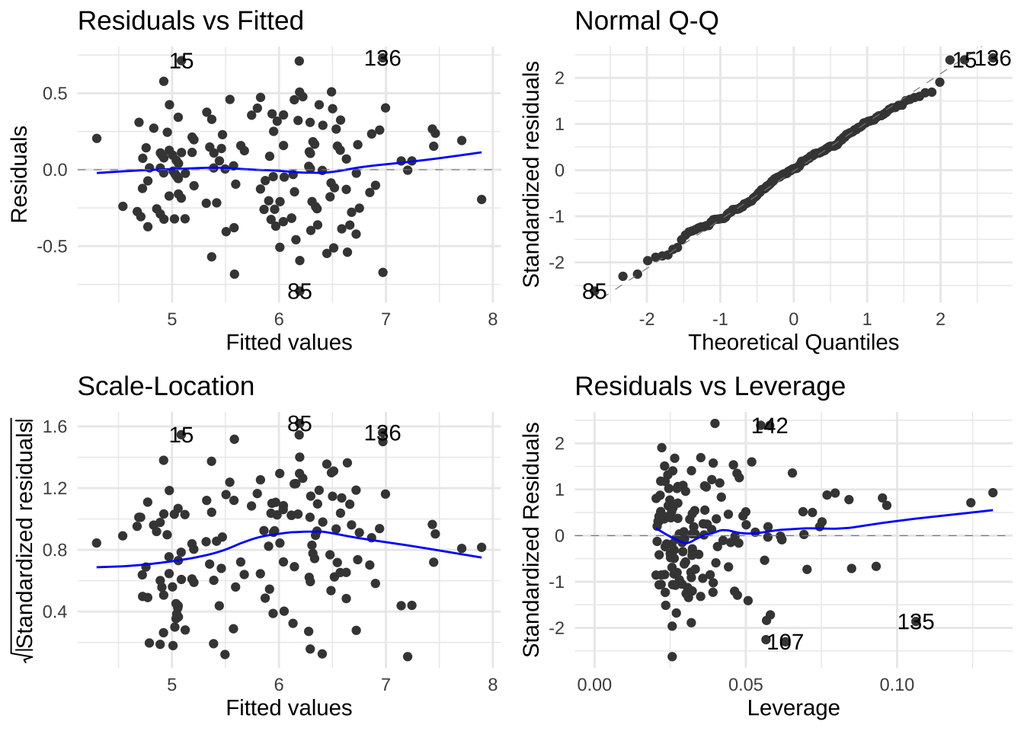

```r
library("ggfortify")
res_lm3 %>%
  ggplot2::autoplot() +
  ggplot2::theme_minimal()
```

**Boxplot**

A boxplot can be useful for checking **influential observations** and visually checking the **homogeneity of variance assumption** when performing an ANOVA. The boxplot below shows the distributions of sepal length for the three iris species (corresponding to the one-way ANOVA example above).

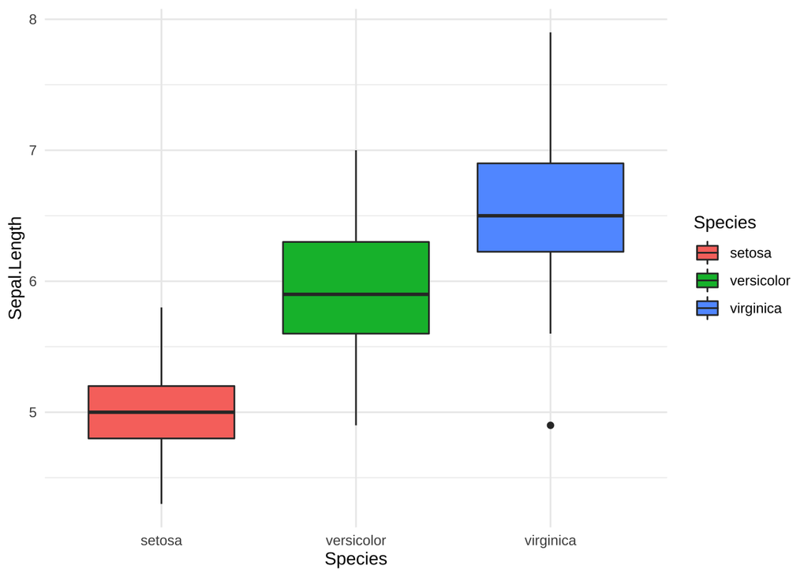

```r
iris %>%
  ggplot2::ggplot(aes(x = Species, y = Sepal.Length, fill = Species)) +
  ggplot2::geom_boxplot() +
  ggplot2::theme_minimal()
```

**Density plot**

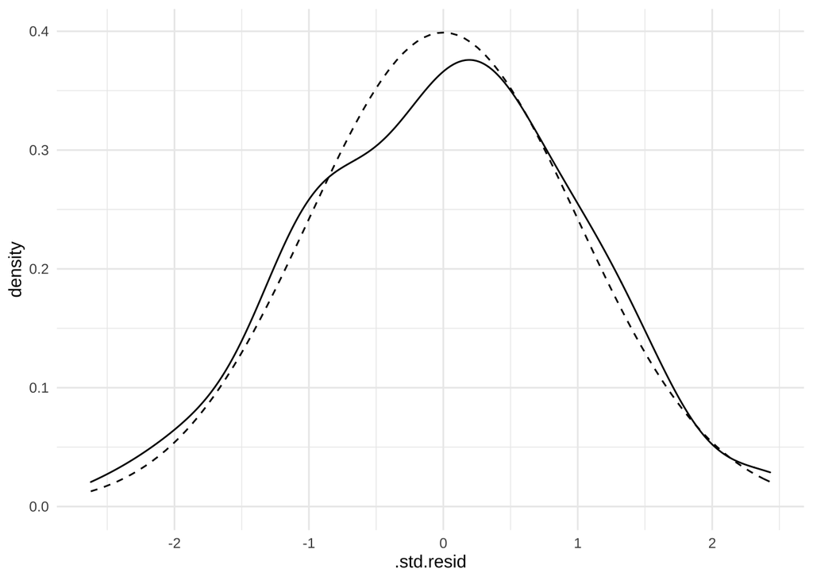

```r
res_lm3 %>% broom::augment() %>%
  ggplot2::ggplot(aes(x = .std.resid)) +
  ggplot2::geom_density(linetype = "solid") +
  ggplot2::stat_function(fun = dnorm, linetype = "dashed") +
  ggplot2::theme_minimal()
```

#### Descriptives

**Correlation matrix**

In the *Data* section of this masterclass it is shown how a correlation matrix (of the independent variables) is created, which can be used to check the **no multicollinearity assumption**.

**Variance inflation factor**

To check the **no multicollinearity assumption** in base R, the [variance inflation factors](https://en.wikipedia.org/wiki/Variance_inflation_factor) are easily computed by inserting the results object of a multiple regression analysis (using the `lm` function) into the `vif` function.

```r
res_lm4 %>% car::vif()
```

#### Tests

**Levene’s test**

With multiple groups, such as in an ANOVA, the **homogeneity of variance assumption** can be checked with the [Levene’s test](https://en.wikipedia.org/wiki/Levene%27s_test) in base R.

```r
res_aov %>% car::leveneTest()  # the default center of each group is the median
res_aov %>% car::leveneTest(center = mean)  # but you can change the center to the mean
```

**Shapiro–Wilk test**

Base R supports a [Shapiro–Wilk test](https://en.wikipedia.org/wiki/Shapiro%E2%80%93Wilk_test) on your standardized residuals, to check the **normality of residuals assumption**.

```r
res_lm3 %>%
  broom::augment() %>%
  dplyr::pull(.std.resid) %>%  # pulls out the vector of your standardized residuals, as discussed in the _We R Novices_ masterclass
  stats::shapiro.test()
```

**Give me more.** There is a tidyverse-friendly function for the Shapiro–Wilk test in the *rstatix* package, which enables you to perform the test per group, but which must be installed and loaded separately.

```r
library(rstatix)
res_lm3 %>%
  broom::augment() %>%
  dplyr::group_by(Species) %>%
  rstatix::shapiro_test(.std.resid)
```

## 3.3 Exercises

In these exercises you will work again with the data used in this chapter’s demonstration script. The demonstration script might serve as a helpful example for most of these exercises.

### Student’s t-test

**Instruction**

Test whether males and females differ in their agreement with the statement *“Computers are complicated machines”*.

**Tips**

- First, create the appropriate model formula using the variable names `female` and `computers`, and then use this formula object in the t-test function.

### Chi-squared test

**Instruction**

The students were randomly assigned to three conditions; students in each group listened to a different song. Let’s check whether the random assignment yielded a roughly equal number of males and females in each of the three conditions.

**Tips**

- First, create the appropriate model formula, and then use this formula object in the chi-squared test function.
- After having performed both a t-test and chi-squared test, your chai tea will never taste the same.

### One-way ANOVA

**Instruction**

Does listening to different songs influence how much the students would enjoy eating at a diner?

- Test the differences in the answer to the statement *“Imagine you were going to a diner for dinner tonight, how much do you think you would like the food?”* between the three groups. Create the appropriate model formula using the variables `cond` and `diner` and use this model object in the `aov` function.
- Extract the omnibus test results using the appropriate function from the *broom* package. Is the difference between the three groups significant?
- Test the homogeneity of variance assumption using the Levene’s test.

**Give me more.** The number of observations is low, so even if the variances between the three groups are different, we might not have enough power to detect these differences with a Levene’s test. Let’s additionally check this assumption visually by creating a box plot.

### Linear regression analysis

**Instruction**

Let’s try to predict students’ political orientation using their dad’s age, mom’s age, and their agreement with the statement *“Computers are complicated machines”*.

- Fit the corresponding linear regression model by creating the model formula and inserting this into the appropriate function.
- Extract the results. Get all relevant output such that you would be able to report the R squared of the model, and the regression coefficients (estimates) for all three independent variables and the corresponding p-values.
- Check multiple assumptions of linear regression visually using the `autoplot` function from the *ggplot2* package.

### Logistic regression

**Instruction**

Predict students’ sex by their political orientation and by their agreement with the statement *“Computers are complicated machines”*. Fit the corresponding logistic regression model and extract the results such that you could report the BIC of the model and the regression coefficients.

### Bug hunt

**Instruction**

Run the following lines of code. What happens? Why?

```r
model <- extra ~ group
sleep %>% infer::t_test(model)
sleep %>% stats::lm(model)
```

**Tips**

The linear regression throws an error. It has something to do with using the pipe operator on a function that is not from the tidyverse.

### Solutions

Use your [*psi*](https://doi.apa.org/doi/10.1037/a0021524) to feel your future R champion and solve the exercises with the expertise that you will obtain in these masterclasses[*](https://en.wikipedia.org/wiki/Daryl_Bem#%22Feeling_the_Future%22_controversy).

## 3.4 Break

[figure not shown]

xkcd.com

## 3.5 Discussion

> Lingering questions or concerns? Use Piazza to post a question or up on our plenary discussion.

# 4 Wrap Up

## 4.1 Practice data sets

*Readily available data sets*

Some R packages contain data that you can freely use. Unfortunately, many data does not come as a data frame or tibble, and is thus not suitable for your needs (below we give a short list of data that is).

- Run `data()` to see which data sets are available in the (loaded) packages.
- Run `data(package = "dplyr")` to look for data sets in the `dplyr` package (replace with any other package).
- Run `help("storms")` to get information on the `storms` data set (replace with any other data set).
- Run `data("storms")` to load the `storms` data set (replace with any other data set).

*Data frames and tibbles*

Data in packages that belong to the tidyverse (such as `dplyr` and `tidyr`), have a higher chance of being in the `tibble()` format that you are now familiar with. Here are some examples that you might find useful.

```r
help("iris")
help("mtcars")
help("storms")  # longitudinal data
```

*Data packages*

Some packages contain only data. There are many such data packages, but you won’t be able to find them easily. One you should definitely check out is the [*modeldata*](https://modeldata.tidymodels.org/reference/index.html) package. It’s part of the tidymodels collections, so you’ve already loaded it. Check the link or run `data(package = "modeldata")` to see which data sets it includes. For a bunch of other data packages follow [this link](https://rviews.rstudio.com/2017/11/01/r-data-packages/), it will give you an overview of some data packages from 2017.

## 4.2 Take home exercises

### Finish the exercises

Continue with the exercises, use Piazza to ask questions.

### Explore your data

Grab some of your own data, tidy it, and load it into R. Start applying what you’ve learned so far!

Don’t have your own data? Or want practice data? Check the previous section to get some tips for using readily available data.

### Toss out TOSS

Working on a research project right now or starting one soon? It’s time to toss out That Other Statistical Software you normally use and force yourself to do the analyses in R. You now know where to find help. And you regularly compare your results with your [co-pilot’s](https://doi.org/10.1371/journal.pone.0114876) results anyway, don’t you?

# 5 Colophon

Created with [R Markdown](https://github.com/rstudio/rmarkdown) and generated on November 19, 2020.

**Reproducibility receipt**

**Session information**

```r
─ Session info ───────────────────────────────────────────────────────────────
 setting  value
 version  R version 4.0.2 (2020-06-22)
 os       macOS Catalina 10.15.7
 system   x86_64, darwin17.0
 ui       X11
 language (EN)
 collate  en_US.UTF-8
 ctype    en_US.UTF-8
 tz       Europe/Amsterdam
 date     2020-11-19

─ Packages ───────────────────────────────────────────────────────────────────
 package      * version    date       lib source
 assertthat     0.2.1      2019-03-21 [1] CRAN (R 4.0.0)
 backports      1.1.10     2020-09-15 [1] CRAN (R 4.0.2)
 BiocManager    1.30.10    2019-11-16 [1] CRAN (R 4.0.0)
 broom        * 0.7.2      2020-10-20 [1] CRAN (R 4.0.2)
 cellranger     1.1.0      2016-07-27 [1] CRAN (R 4.0.0)
 class          7.3-17     2020-04-26 [1] CRAN (R 4.0.2)
 cli            2.1.0      2020-10-12 [1] CRAN (R 4.0.2)
 clipr          0.7.0      2019-07-23 [1] CRAN (R 4.0.0)
 codetools      0.2-16     2018-12-24 [1] CRAN (R 4.0.2)
 colorspace     1.4-1      2019-03-18 [1] CRAN (R 4.0.0)
 corrr          0.4.2      2020-03-22 [1] CRAN (R 4.0.2)
 crayon         1.3.4      2017-09-16 [1] CRAN (R 4.0.0)
 DBI            1.1.0      2019-12-15 [1] CRAN (R 4.0.0)
 dbplyr         2.0.0      2020-11-03 [1] CRAN (R 4.0.2)
 desc           1.2.0      2018-05-01 [1] CRAN (R 4.0.0)
 details      * 0.2.1      2020-01-12 [1] CRAN (R 4.0.0)
 dials        * 0.0.9      2020-09-16 [1] CRAN (R 4.0.2)
 DiceDesign     1.8-1      2019-07-31 [1] CRAN (R 4.0.0)
 digest         0.6.25     2020-02-23 [1] CRAN (R 4.0.0)
 dplyr        * 1.0.2      2020-08-18 [1] CRAN (R 4.0.2)
 ellipsis       0.3.1      2020-05-15 [1] CRAN (R 4.0.0)
 evaluate       0.14       2019-05-28 [1] CRAN (R 4.0.0)
 fansi          0.4.1      2020-01-08 [1] CRAN (R 4.0.0)
 farver         2.0.3      2020-01-16 [1] CRAN (R 4.0.0)
 forcats      * 0.5.0      2020-03-01 [1] CRAN (R 4.0.0)
 foreach        1.5.0      2020-03-30 [1] CRAN (R 4.0.0)
 fs             1.5.0      2020-07-31 [1] CRAN (R 4.0.2)
 furrr          0.1.0      2018-05-16 [1] CRAN (R 4.0.0)
 future         1.19.1     2020-09-22 [1] CRAN (R 4.0.2)
 generics       0.1.0      2020-10-31 [1] CRAN (R 4.0.2)
 ggfortify    * 0.4.10     2020-04-26 [1] CRAN (R 4.0.2)
 ggimage        0.2.8      2020-04-02 [1] CRAN (R 4.0.0)
 ggplot2      * 3.3.2      2020-06-19 [1] CRAN (R 4.0.0)
 ggplotify      0.0.5      2020-03-12 [1] CRAN (R 4.0.0)
 git2r        * 0.27.1     2020-05-03 [1] CRAN (R 4.0.0)
 globals        0.13.0     2020-09-17 [1] CRAN (R 4.0.2)
 glue           1.4.2      2020-08-27 [1] CRAN (R 4.0.2)
 gower          0.2.2      2020-06-23 [1] CRAN (R 4.0.2)
 GPfit          1.0-8      2019-02-08 [1] CRAN (R 4.0.0)
 gridExtra      2.3        2017-09-09 [1] CRAN (R 4.0.0)
 gridGraphics   0.5-0      2020-02-25 [1] CRAN (R 4.0.0)
 gtable         0.3.0      2019-03-25 [1] CRAN (R 4.0.0)
 haven          2.3.1      2020-06-01 [1] CRAN (R 4.0.2)
 hexbin         1.28.1     2020-02-03 [1] CRAN (R 4.0.0)
 hexSticker   * 0.4.7      2020-06-01 [1] CRAN (R 4.0.0)
 highr          0.8        2019-03-20 [1] CRAN (R 4.0.0)
 hms            0.5.3      2020-01-08 [1] CRAN (R 4.0.0)
 htmltools      0.5.0      2020-06-16 [1] CRAN (R 4.0.2)
 httr           1.4.2      2020-07-20 [1] CRAN (R 4.0.2)
 infer        * 0.5.3      2020-07-14 [1] CRAN (R 4.0.2)
 ipred          0.9-9      2019-04-28 [1] CRAN (R 4.0.0)
 iterators      1.0.12     2019-07-26 [1] CRAN (R 4.0.0)
 jsonlite       1.7.1      2020-09-07 [1] CRAN (R 4.0.2)
 knitr          1.30       2020-09-22 [1] CRAN (R 4.0.2)
 labeling       0.3        2014-08-23 [1] CRAN (R 4.0.0)
 lattice        0.20-41    2020-04-02 [1] CRAN (R 4.0.2)
 lava           1.6.8      2020-09-26 [1] CRAN (R 4.0.2)
 lhs            1.1.0      2020-09-29 [1] CRAN (R 4.0.2)
 lifecycle      0.2.0      2020-03-06 [1] CRAN (R 4.0.0)
 listenv        0.8.0      2019-12-05 [1] CRAN (R 4.0.0)
 lubridate      1.7.9      2020-06-08 [1] CRAN (R 4.0.2)
 magick         2.4.0      2020-06-23 [1] CRAN (R 4.0.2)
 magrittr       1.5        2014-11-22 [1] CRAN (R 4.0.0)
 MASS           7.3-53     2020-09-09 [1] CRAN (R 4.0.2)
 Matrix         1.2-18     2019-11-27 [1] CRAN (R 4.0.2)
 modeldata    * 0.1.0      2020-10-22 [1] CRAN (R 4.0.2)
 modelr         0.1.8      2020-05-19 [1] CRAN (R 4.0.2)
 munsell        0.5.0      2018-06-12 [1] CRAN (R 4.0.0)
 nnet           7.3-14     2020-04-26 [1] CRAN (R 4.0.2)
 parsnip      * 0.1.4      2020-10-27 [1] CRAN (R 4.0.2)
 pillar         1.4.6      2020-07-10 [1] CRAN (R 4.0.2)
 pkgconfig      2.0.3      2019-09-22 [1] CRAN (R 4.0.0)
 plotrix      * 3.7-8      2020-04-16 [1] CRAN (R 4.0.2)
 plyr           1.8.6      2020-03-03 [1] CRAN (R 4.0.0)
 png            0.1-7      2013-12-03 [1] CRAN (R 4.0.0)
 pROC           1.16.2     2020-03-19 [1] CRAN (R 4.0.0)
 prodlim        2019.11.13 2019-11-17 [1] CRAN (R 4.0.0)
 purrr        * 0.3.4      2020-04-17 [1] CRAN (R 4.0.0)
 R6             2.4.1      2019-11-12 [1] CRAN (R 4.0.0)
 Rcpp           1.0.5      2020-07-06 [1] CRAN (R 4.0.2)
 readr        * 1.4.0      2020-10-05 [1] CRAN (R 4.0.2)
 readxl         1.3.1      2019-03-13 [1] CRAN (R 4.0.0)
 recipes      * 0.1.15     2020-11-11 [1] CRAN (R 4.0.2)
 reprex         0.3.0      2019-05-16 [1] CRAN (R 4.0.0)
 rlang          0.4.8      2020-10-08 [1] CRAN (R 4.0.2)
 rmarkdown      2.4        2020-09-30 [1] CRAN (R 4.0.2)
 rpart          4.1-15     2019-04-12 [1] CRAN (R 4.0.2)
 rprojroot      1.3-2      2018-01-03 [1] CRAN (R 4.0.0)
 rsample      * 0.0.8      2020-09-23 [1] CRAN (R 4.0.2)
 rstudioapi     0.13       2020-11-12 [1] CRAN (R 4.0.2)
 rvcheck        0.1.8      2020-03-01 [1] CRAN (R 4.0.0)
 rvest          0.3.6      2020-07-25 [1] CRAN (R 4.0.2)
 scales       * 1.1.1      2020-05-11 [1] CRAN (R 4.0.0)
 sessioninfo  * 1.1.1      2018-11-05 [1] CRAN (R 4.0.0)
 showtext       0.9        2020-08-13 [1] CRAN (R 4.0.2)
 showtextdb     3.0        2020-06-04 [1] CRAN (R 4.0.0)
 stringi        1.5.3      2020-09-09 [1] CRAN (R 4.0.2)
 stringr      * 1.4.0      2019-02-10 [1] CRAN (R 4.0.0)
 survival       3.2-7      2020-09-28 [1] CRAN (R 4.0.2)
 sysfonts       0.8.1      2020-05-08 [1] CRAN (R 4.0.0)
 tibble       * 3.0.4      2020-10-12 [1] CRAN (R 4.0.2)
 tidymodels   * 0.1.1      2020-07-14 [1] CRAN (R 4.0.2)
 tidyr        * 1.1.2      2020-08-27 [1] CRAN (R 4.0.2)
 tidyselect     1.1.0      2020-05-11 [1] CRAN (R 4.0.0)
 tidyverse    * 1.3.0      2019-11-21 [1] CRAN (R 4.0.2)
 timeDate       3043.102   2018-02-21 [1] CRAN (R 4.0.0)
 tune         * 0.1.1      2020-07-08 [1] CRAN (R 4.0.2)
 utf8           1.1.4      2018-05-24 [1] CRAN (R 4.0.0)
 vctrs          0.3.4      2020-08-29 [1] CRAN (R 4.0.2)
 withr          2.3.0      2020-09-22 [1] CRAN (R 4.0.2)
 workflows    * 0.2.1      2020-10-08 [1] CRAN (R 4.0.2)
 xfun           0.18       2020-09-29 [1] CRAN (R 4.0.2)
 xml2           1.3.2      2020-04-23 [1] CRAN (R 4.0.0)
 yaml           2.2.1      2020-02-01 [1] CRAN (R 4.0.0)
 yardstick    * 0.0.7      2020-07-13 [1] CRAN (R 4.0.2)

[1] /Library/Frameworks/R.framework/Versions/4.0/Resources/library
```

**License**

We R Analysts by Alexander Savi & Simone Plak is licensed under a [Creative Commons Attribution-ShareAlike 4.0 International License](https://creativecommons.org/licenses/by-sa/4.0/). An [Open Educational Resource](https://en.wikipedia.org/wiki/Open_educational_resources). Approved for [Free Cultural Works](https://en.wikipedia.org/wiki/Definition_of_Free_Cultural_Works).